# 🇺🇸 THE STORY OF AMERICA'S MASS KILLINGS 🇺🇸

## 从美国大型枪击事件看到枪支暴力问题

**概述：**

**数据来源：**

- us-mass-shootings-last-50-years
- gun-violence-data
- [Pew Research Center](https://www.pewresearch.org/)

**集体射击的定义：**

3个或更多的射击受害者（不一定是死亡人数），不包括射击者。枪击事件不得与帮派，毒品或有组织犯罪有关。

**探讨的问题：**

- 每年有多少人被杀或受伤？
- 枪手与他/她的种族，性别之间是否有任何关联？
- 哪些城市和州更容易遭受此类攻击？
- 多少枪手存在某种心理健康问题？

## 1⃣️ 🔍我们先看看美国私人拥枪的数据

```python
from pyecharts.faker import Faker
from pyecharts import options as opts
from pyecharts.charts import Bar,Line

def overlap_line_scatter() -> Bar:
    x =  ["1996", "2000", "2009"]
    bar = (
        Bar()
        .add_xaxis(x)
        .add_yaxis("美国人口", ['243000000','259000000','310000000'])
        .set_global_opts(title_opts=opts.TitleOpts(title="美国私人拥枪的数据对比"))
    )
    line = (
        Line()
        .add_xaxis(x)
        .add_yaxis("美国拥枪人数", ['263000000','282000000','307000000'])
    )
    bar.overlap(line)
    return bar

overlap_line_scatter().render_notebook()
```

## 2⃣️ 🗺在美国地图上可视化大规模枪击事件（1966-2017年）

我们先来看看美国哪些地方发生了大规模的枪击事件。从下图的美国地图中可以看出，美国的大规模枪击案多数集中在东部地区和沿海地区。

```python
import folium
import pandas as pd

# 定义世界地图
world_map = folium.Map()

# 经纬度设置
latitude = 37.77
longitude = -93

# 将“美国大规模射击”全部读入，读取“美国大规模射击”数据集；完整数据应为398条。已提前清理缺失数据
cdata1 = pd.read_csv('Mass.csv', encoding='ISO-8859-1', sep=',' )
cdata1

data = cdata1

# Instantiate a feature group for the incidents in the dataframe
incidents = folium.map.FeatureGroup()

# 将每个枪击案件添加到事件特性组
for lat, lng, in zip(cdata1.latitude, data.longitude):
    incidents.add_child(
        folium.CircleMarker(
            [lat, lng],
            radius=7, # define how big you want the circle markers to be
            color='yellow',
            fill=True,
            fill_color='red',
            fill_opacity=0.4
        )
    )

# Add incidents to map
san_map = folium.Map(location=[latitude, longitude], zoom_start=4)
san_map.add_child(incidents)
```

[interactive chart not shown]

```python
# 统计事件，事件打上标签

from folium import plugins

# let's start again with a clean copy of the map of United State
san_map = folium.Map(location = [latitude, longitude], zoom_start = 4)

# instantiate a mark cluster object for the incidents in the dataframe
incidents = plugins.MarkerCluster().add_to(san_map)

# loop through the dataframe and add each data point to the mark cluster
for lat, lng, label, in zip(data.latitude, data.longitude, cdata1.Title):
    folium.Marker(
        location=[lat, lng],
        icon=None,
        popup=label,
    ).add_to(incidents)

# add incidents to map
san_map.add_child(incidents)
```

[interactive chart not shown]

## 3⃣️ 更加直观——选择你想查看的州数据

```python
# 在py上运行，可视化交互美国地图

from flask import Flask, render_template, request
import pandas as pd

# 模块读进来, 组合拳  组合拳  组合拳
import cufflinks as cf
import plotly as py
import plotly.graph_objs as go

app = Flask(__name__)

# 准备工作
# pandas 大法读内容, 用dropna()丢缺失值, 用unique()取唯一值, 不重覆
df = pd.read_csv('Mass_nd.csv', encoding='ISO-8859-1', sep=',' )
regions_available_loaded = list(df.code.dropna().unique())

# 基本cufflinks 及ploty設置, 查文檔看書貼上而已
cf.set_config_file(offline=True, theme="ggplot")
py.offline.init_notebook_mode()


@app.route('/',methods=['GET'])
def hu_run_2019():

    data_str = df.to_html()  # 使用pandas 数据框之方法.to_html() !! 取代原 "Hello"
                             # pandas真是数据科学家的好朋友!

    regions_available = regions_available_loaded #下拉选单有内容
    return render_template('results2.html',
                           the_res = data_str,   # 表
                           the_select_region=regions_available)

@app.route('/hurun',methods=['POST'])
def hu_run_select() -> 'html':

    the_region = request.form["the_region_selected"]  ## 取得用户交互输入
    print(the_region)                                 ## 检查用户输入, 在后台

    dfs = df.query("code=='{}'".format(the_region)) ## 使用df.query()方法. 按用户交互输入the_region过滤

    data_str = dfs.to_html()  # 数据产出dfs, 完成互动过滤呢

    ## plot_all = "交互式图还没做好" # <------------------交互式图  其實應該放這, 按過濾出的數據來做圖
    ## 交互式可视化画图
    #时间格式的转换

    fig = go.Figure(data=go.Choropleth(
        locations=dfs['code'], # Spatial coordinates
        z = dfs['total'].astype(float), # Data to be color-coded
        locationmode = 'USA-states', # set of locations match entries in `locations`
        colorscale = 'Reds',
        colorbar_title = "Millions USD",
    ))

    fig.update_layout(
        title_text = '美国大型枪击事件',
        geo_scope='usa', # limite map scope to USA
    )

    fig.show()
    py.offline.plot(fig, filename="成果.html",auto_open=False)

    with open("成果.html", encoding="utf8", mode="r") as f:                     # 把"成果.html"當文字檔讀入成字符串
        plot_all = "".join(f.readlines())

    regions_available =  regions_available_loaded #下拉选单有内容
    return render_template('results2.html',
                            the_plot_all = plot_all,
                            the_res = data_str,
                            the_select_region=regions_available,
                           )

if __name__ == '__main__':
    app.run(port = 8005)   # debug=True, 在py使用, 在ipynb不使用
```

[output not shown]

## 4⃣️ 🔥每年受到伤害的人有多少？

- 现在看看自从1966年开始，有多少人在这些大型枪击事件中受到攻击。
- 在2016年左右，受害者的人数激增，那么在2016年前后，美国发生了什么大型的枪击事件？

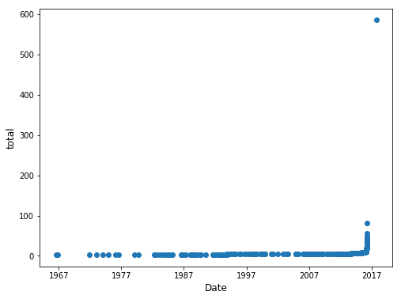

```python
import numpy as np # linear algebra
import matplotlib.pyplot as plt
from subprocess import check_output


# Any results you write to the current directory are saved as output.

cdata1 = pd.read_csv('Mass.csv', encoding = "ISO-8859-1", parse_dates=["Date"])

plt.figure(figsize=(8,6))
plt.scatter(np.sort(cdata1['Date']), np.sort(cdata1['total'].values))
plt.xlabel('Date', fontsize=12)
plt.ylabel('total', fontsize=12)
plt.show()
```

### 拉斯维加斯枪击事件

- 从下面的表格可以看到，伤亡人数最多的一次案件便是2017年10月1日在拉斯维加斯的枪击事件，造成了伤亡共585人。此次袭击是美国最为惨烈的大规模枪击案。
- 枪手是名男性白种人，精神状态不详。因为在逮捕前枪手已死亡。

```python
# 对‘total’进行降序
people=cdata1.sort_values(by="total" , ascending=False)
people
```

|  | S# | Title | Location | Date | Summary | Fatalities | Injured | total | x | Race | Gender | latitude | longitude |
| --- | --- | --- | --- | --- | --- | --- | --- | --- | --- | --- | --- | --- | --- |
| 0 | 1 | Las Vegas Strip mass shooting | Las Vegas, NV | 2017-10-01 | NaN | 58 | 527 | 585 | Unclear | White | Male | 36.181271 | -115.134132 |
| 162 | 180 | Aurora theater shooting | Aurora, Colorado | 2012-07-20 | James Holmes, 24, opened fire in a movie theat... | 12 | 70 | 82 | Yes | white | Male | 39.709283 | -104.823488 |
| 200 | 218 | Virginia Tech massacre | Blacksburg, Virginia | 2007-04-16 | Virginia Tech student Seung-Hui Cho, 23, opene... | 32 | 23 | 55 | Yes | Asian | Male | 37.229573 | -80.413939 |
| 302 | 320 | University of Texas at Austin | Austin, Texas | 1966-08-01 | On August 1, 1966, a 25-year-old engineering s... | 17 | 32 | 48 | Yes | White American or European American | Male | 30.198887 | -97.844159 |
| 181 | 199 | Fort Hood Army Base | Fort Hood, Texas | 2009-11-05 | On November 5, 2009, a 39-year old U.S. Army p... | 13 | 32 | 45 | Yes | White American or European American | Male | 31.138144 | -97.777978 |
| 267 | 285 | Luby's Cafeteria in Killeen, Texas | Killeen, Texas | 1991-10-16 | On October 16, 1991, a 35-year old unemployed ... | 24 | 20 | 43 | Yes | White American or European American | Male | 31.079255 | -97.733923 |
| 286 | 304 | McDonald's restaurant in San Ysidro | San Ysidro, California | 1984-07-18 | On July 18, 1984, a 41-year-old unemployed man... | 22 | 19 | 40 | Yes | White American or European American | Male | 32.555556 | -117.047656 |
| 229 | 247 | Columbine High School | Littleton, Colorado | 1999-04-20 | On April 20, 1999, two students ages 17 and 18... | 15 | 24 | 37 | Yes | White American or European American | Male | 39.593583 | -105.015211 |
| 65 | 79 | San Bernardino, California | San Bernardino, California | 2015-12-02 | On Wednesday of December 2, 2015, two gunmen e... | 16 | 21 | 35 | Unknown | Asian American | Male/Female | 34.139734 | -117.294244 |
| 273 | 291 | Cleveland Elementary School | Stockton, California | 1989-01-17 | On January 17, 1989, an unemployed 24-year-old... | 6 | 30 | 35 | Yes | White American or European American | Male | 37.966318 | -121.301877 |
| 156 | 174 | Sandy Hook Elementary School | Newtown, Connecticut | 2012-12-14 | On December 14, 2012, a 20-year old shot and k... | 28 | 2 | 29 | Yes | White American or European American | Male | 41.411908 | -73.311963 |
| 231 | 249 | Thurston High School | Springfield, Oregon | 1998-05-21 | On May 21, 1998, a 15-year-old student at Thur... | 4 | 25 | 29 | Yes | White American or European American | Male | 44.054897 | -123.007556 |
| 250 | 268 | Fairchild Air Force Base Hospital | Fairchild Air Force Base, Washington | 1994-06-20 | On June 20, 1994, a 20-year-old discharged tec... | 5 | 23 | 27 | Yes | White American or European American | Male | 47.618456 | -117.644099 |
| 191 | 209 | Northern Illinois University shooting | DeKalb, Illinois | 2008-02-14 | Steven Kazmierczak, 27, opened fire in a lectu... | 5 | 21 | 26 | Yes | white | Male | 41.929474 | -88.750365 |
| 254 | 272 | Long Island Rail Road Commuter Train | Garden City, New York | 1993-12-07 | On December 7, 1993, a 34-year-old mentally un... | 6 | 19 | 25 | No | Black American or African American | Male | 40.726623 | -73.644712 |
| 299 | 317 | New Orleans Police Shootings | New Orleans, Louisiana | 1972-12-31 | On New Year's Eve in 1972, a 23-year-old ex-Na... | 10 | 13 | 22 | Yes | Black American or African American | Male | 30.068724 | -89.931474 |
| 227 | 245 | Offices of All-Tech Investment Group and Momen... | Atlanta, Georgia | 1999-07-29 | On July 29, 1999, after murdering his wife and... | 10 | 12 | 21 | Yes | White American or European American | Male | 33.762997 | -84.423133 |
| 282 | 300 | Post office in Edmond, Oklahoma | Edmond, Oklahoma | 1986-08-20 | On August 20, 1986, a 44-year-old postal worke... | 15 | 6 | 20 | Yes | White American or European American | Male | 35.668892 | -97.414388 |
| 271 | 289 | Standard Gravure Corporation | Louisville, Kentucky | 1989-09-14 | On September 14. 1989, a 47-year-old man, disg... | 9 | 12 | 20 | Yes | White American or European American | Male | 38.249432 | -85.726243 |
| 280 | 298 | Palm Bay Shopping Centers | Palm Bay, Florida | 1987-04-23 | On April 23, 1987, a 59-year-old retired libra... | 6 | 14 | 20 | Yes | White American or European American | Male | 27.983890 | -80.666627 |
| 176 | 194 | Tucson shooting | Tucson, Arizona | 2011-01-08 | Jared Loughner, 22, opened fire outside a Safe... | 6 | 13 | 19 | Yes | white | Male | 32.221743 | -110.926479 |
| 137 | 155 | Fort Hood | Killeen, Texas | 2014-04-02 | On April 2, 2014, a 34-year-old Army Specialis... | 4 | 16 | 19 | Yes | Some other race | Male | 31.079255 | -97.733923 |
| 182 | 200 | Binghamton shootings | Binghamton, New York | 2009-04-03 | Jiverly Wong, 41, opened fire at an American C... | 14 | 4 | 18 | Yes | Asian | Male | 42.098687 | -75.917974 |
| 270 | 288 | GMAC Loan Office | Jacksonville, Florida | 1990-06-17 | After fatally shooting a man and woman and wou... | 12 | 6 | 17 | No | Black American or African American | Male | 30.332161 | -81.675770 |
| 38 | 50 | Hesston, Kansas | Hesston, Kansas | 2016-02-25 | On Friday, 90 minutes after receiving a court ... | 4 | 14 | 17 | Unknown | Black American or African American | Male | 38.136800 | -97.426800 |
| 75 | 90 | Umpqua Community College | Roseburg, Oregon | 2015-10-01 | On Monday of October 1, 2015, a gunman opened ... | 10 | 7 | 16 | Unknown | Two or more races | Male | 43.222056 | -123.352237 |
| 186 | 204 | Geneva County, Alabama | Geneva, Alabama | 2009-03-10 | On March 10, 2009, a 28-year-old grocery worke... | 11 | 6 | 16 | No | White American or European American | Male | 31.043676 | -85.876347 |
| 216 | 234 | Lockheed Martin shooting | Meridian, Mississippi | 2003-07-08 | Assembly line worker Douglas Williams, 48, ope... | 7 | 8 | 15 | Yes | white | Male | 32.376081 | -88.689780 |
| 233 | 251 | Westside Middle School killings | Jonesboro, Arkansas | 1998-03-24 | Mitchell Scott Johnson, 13, and Andrew Douglas... | 5 | 10 | 15 | No | white | Male | 35.820990 | -90.668261 |
| 143 | 161 | Washington Navy Yard | Washington D.C. | 2013-09-16 | On September 16, 2013, a 34-yearl old contract... | 13 | 3 | 15 | Yes | Black American or African American | Male | 38.904809 | -77.016297 |
| ... | ... | ... | ... | ... | ... | ... | ... | ... | ... | ... | ... | ... | ... |
| 142 | 160 | Sparks Middle School | Sparks, Nevada | 2013-10-21 | On October 21, 2013, a 12-year old student at ... | 2 | 2 | 3 | Unknown | Some other race | Male | 39.540584 | -119.748291 |
| 217 | 235 | Case Western Reserve University | Cleveland, Ohio | 2003-05-09 | On May 9, 2003, a graduate of the Case Western... | 1 | 2 | 3 | No | Asian American | Male | 41.476576 | -81.680515 |
| 134 | 150 | Nellis Plaza | Las Vegas, Nevada | 2014-06-08 | On the afternoon of June 8, 2014, a man and hi... | 5 | 0 | 3 | No | White American or European American | Male/Female | 36.189319 | -115.326487 |
| 121 | 137 | King, North Carolina | King, North Carolina | 2015-02-04 | A Couple and their sons were found shot to dea... | 4 | 0 | 3 | Unknown | White American or European American | Male | 36.276179 | -80.355014 |
| 117 | 133 | Chapel Hill | Chapel Hill, North Carolina | 2015-02-10 | On the evening of Feb. 10, 2015, a man entered... | 3 | 0 | 3 | No | White American or European American | Male | 35.926815 | -79.038504 |
| 76 | 91 | Inglis, Florida | Inglis, Florida | 2015-10-01 | A man 57-year-old man shot and killed his wife... | 3 | 1 | 3 | Unknown | White American or European American | Male | 29.032706 | -82.659193 |
| 218 | 236 | University of Arizona College of Nursing | Tucson, Arizona | 2002-10-28 | On October 28, 2002, a 41-year-old nursing stu... | 4 | 0 | 3 | No | Some other race | Male | 32.153589 | -110.967765 |
| 241 | 259 | San Diego State University | San Diego, California | 1996-08-15 | On August 15, 1996, a 36-year-old mechanical e... | 3 | 0 | 3 | No | White American or European American | Male | 32.863573 | -117.128163 |
| 92 | 108 | Cleveland | Cleveland, Ohio | 2015-05-31 | On May 31, 2015, the shooter entered his ex-gi... | 3 | 1 | 3 | Unknown | Unknown | Male | 41.476576 | -81.680515 |
| 81 | 96 | Virginia WDBJ live TV interview shooting | Roanoke, Virginia | 2015-08-26 | Wednesday morning on August 26, 2015, a former... | 3 | 1 | 3 | Unknown | Black American or African American | Male | 37.278234 | -79.958161 |
| 252 | 270 | Chelsea High School | Chelsea, Michigan | 1993-12-16 | On December 16, 1993, after a meeting with sch... | 1 | 2 | 3 | Yes | White American or European American | Male | 42.313194 | -84.018681 |
| 189 | 207 | South Mountain Community College | Phoenix, Arizona | 2008-07-24 | On July 24, 2008, a 24-year-old man arrived at... | 0 | 3 | 3 | No | Black American or African American | Male | 33.571459 | -112.090485 |
| 188 | 206 | University of Central Arkansas | Conway, Arkansas | 2008-10-26 | On October 26, 2008, four men between the ages... | 0 | 1 | 3 | No | Black American or African American | Male | 35.081307 | -92.432783 |
| 47 | 60 | Michigan school shooting | NaN | 2016-02-09 | Shooter was a part of a fight outside of a hig... | 0 | 3 | 3 | Unknown | Black American or African American | Male | 43.201126 | -86.238946 |
| 257 | 275 | Weber State University | Ogden, Utah | 1993-07-08 | On July 8, 1993, a 28-year old student shot an... | 1 | 3 | 3 | No | Asian American | Male | 41.228137 | -111.967532 |
| 259 | 277 | Dearborn Post Office | Dearborn, Michigan | 1993-05-06 | On May 6, 1993, a 45-year-old postal mechanic,... | 2 | 2 | 3 | Unknown | Unknown | Male | 42.312695 | -83.212932 |
| 52 | 65 | Texas teen commits family murder suicide | NaN | 2016-02-06 | 19-year-old male kills his mother and two neig... | 4 | 0 | 3 | Unknown | White American or European American | Male | 29.209684 | -99.786168 |
| 235 | 253 | Milwaukee Post Office | Milwaukee, Wisconsin | 1997-12-19 | On December 19, 1997, a 37-year-old postal wor... | 2 | 2 | 3 | No | Black American or African American | Male | 43.064203 | -87.967244 |
| 23 | 34 | Elberton, Georgia murder-suicide | NaN | 2016-03-12 | Domestic dispute led a man to shoot his girlfr... | 2 | 2 | 3 | Unknown | Unknown | Male | 34.111223 | -82.867084 |
| 206 | 224 | Orange High School | Hillsborough, North Carolina | 2006-08-30 | On August 30, 2006, a 18-year old former stude... | 1 | 2 | 3 | Yes | Some other race | Male | 36.040999 | -79.097012 |
| 105 | 121 | Tulsa | Tulsa, Oklahoma | 2015-03-30 | On March 30, 2015, police discovered four bodi... | 4 | 0 | 3 | Unknown | Asian American | Male | 36.135432 | -95.913161 |
| 107 | 123 | Little Water | Little Water, New Mexico | 2015-03-19 | On March 19, 2015, police officer was shot and... | 2 | 2 | 3 | Unknown | Unknown | Male | 36.443290 | -108.723281 |
| 53 | 66 | New Orleans gas station shoot-out | NaN | 2016-01-31 | Altercation broke out at a gas station in New ... | 0 | 3 | 3 | Unknown | Black American or African American | Male | 29.951066 | -90.071532 |
| 109 | 125 | Cottonwood | Cottonwood, Alabama | 2015-03-15 | On Sunday night of March 15, the man broke int... | 3 | 1 | 3 | No | White American or European American | Male | 31.054969 | -85.301001 |
| 268 | 286 | Ridgewood Post Office | Ridgewood, New Jersey | 1991-10-10 | On October 10, 1991, a 35-year old former post... | 3 | 0 | 3 | Yes | Black American or African American | Male | 40.982133 | -74.112647 |
| 111 | 127 | Tarboro | Tarboro, North Carolina | 2015-02-28 | On Saturday afternoon of February 28, 2015, on... | 4 | 0 | 3 | Yes | Black American or African American | Male | 35.904345 | -77.556400 |
| 112 | 128 | Birmingham's Washington Park | Birmingham, Alabama | 2015-02-27 | On February 27, 2015, the online Facebook braw... | 1 | 2 | 3 | No | Black American or African American | Male | 33.528287 | -86.795504 |
| 114 | 130 | Charlotte | Charlotte, North Carolina | 2015-02-24 | On February 24, 2015, "America's Next Top Mode... | 3 | 0 | 3 | No | Some other race | Male | 35.226354 | -80.836788 |
| 55 | 68 | Caroline County, VA Family Murder Suicide | NaN | 2016-01-29 | 42-year-old husband murders wife, shoots two y... | 2 | 2 | 3 | Unknown | Unknown | Male | 38.044556 | -77.286488 |
| 135 | 151 | Seattle Pacific University | Seattle, Washington | 2014-06-05 | On June 5, 2014, a 26-year-old man entered a h... | 1 | 2 | 3 | Yes | Some other race | Male | 47.621996 | -122.323646 |

303 rows × 13 columns

## 5⃣️ 🔥每年发生的大型枪击事件又有多少呢？

- 下面柱形图是每年大型枪击事件发生的次数，可以看到2015年和2016年发生了(>60起)多起的枪击事件。

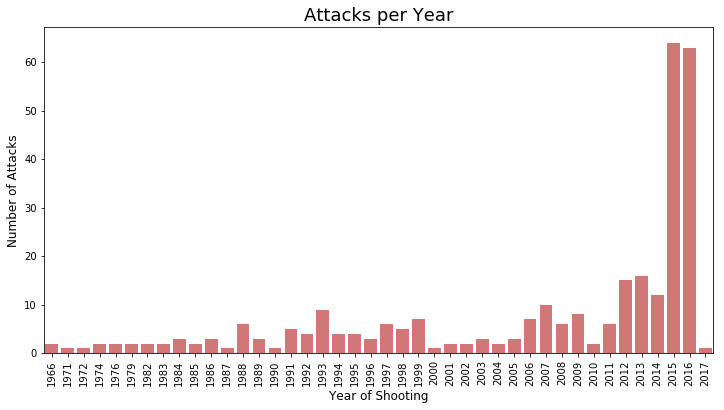

```python
import numpy as np # linear algebra
import pandas as pd # data processing, CSV file I/O (e.g. pd.read_csv)
import matplotlib.pyplot as plt
import matplotlib.cm as cm
import matplotlib as mpl
import seaborn as sns
color = sns.color_palette()

%matplotlib inline

# Any results you write to the current directory are saved as output.

mass_shooting = pd.read_csv('Mass.csv', encoding = "ISO-8859-1", parse_dates=["Date"])

mass_shooting.head(10) # shows top 5 entries of the file

mass_shooting['Year'] = mass_shooting['Date'].dt.year     # seperates years from date
year = mass_shooting['Year'].value_counts()           # counts values according to specific year
plt.figure(figsize=(12,6))                                # decides size of plot
sns.barplot(year.index, year.values, alpha=0.7, color=color[3])
"""
Color
0 Blue
1 Orange
2 Green
3 Red
"""
plt.xticks(rotation='vertical')  # makes x axis values vrertical
plt.xlabel('Year of Shooting', fontsize=12)  # fontsize and label
plt.ylabel('Number of Attacks', fontsize=12)  # fontsize and label
plt.title('Attacks per Year', fontsize=18) # fontsize and label
plt.show()
```

# 6⃣️ 枪手

## 🤔枪手的种族

- 从图中可以看到，多数的袭击者以美国白人为主，之后便是美国黑人。不过总的来说，袭击者总人数属于白种人类别。
- 同时[《America’s Complex Relationship With Guns》](https://www.pewsocialtrends.org/2017/06/22/americas-complex-relationship-with-guns/)这份报告就指出：白人特别有可能是枪支拥有者，但所有权跨越了人口界限。

```python
import plotly.graph_objects as go

#列出枪手的种族
data2=cdata1.Race

labels = ['White American or European American', 'Black American or African American  ', 'Unknown  ',
       'Some other race', 'white',
       'Asian American  ', 'Asian  ',
       'Native American or Alaska Native',
       'black',
       'White', 'Latino', 'Two or more races', 'Asian American/Some other race ',
       'White American or European American/Some other Race', 'Black American or African American/Unknown']
values = ['122',' 76', '42', '20',' 12', '11',' 5', '3', '3', '2', '2', '2', '1', '1', '1']

fig = go.Figure(data=[go.Pie(labels=labels, values=values)])
fig.show()
```

[interactive chart not shown]

## 🤔枪手的性别

- 以男性居多，女性占比非常小。
- 社会不公平导致恶性事件增多，美国滥杀枪手多为压力大的男性。

```python
import plotly.graph_objects as go

# 统计
gender=cdata1.Gender
gender2=gender.value_counts()

labels = ['Male', 'Unknown',
       'Female', 'Male/Female']
values = [273,21, 5, 4]

fig = go.Figure(data=[go.Pie(labels=labels, values=values)])
fig.show()
```

[interactive chart not shown]

## 🤔枪手的精神状态

- 除去一些不详的数据，精神状态有问题与没有问题差不多是1:1的关系。

```python
import plotly.graph_objects as go

mental=cdata1.x
mental2=mental.value_counts()

labels = ['Unknown', 'Yes', 'No',
       'Unclear']
values = ['111',' 99', '90', '3']

fig = go.Figure(data=[go.Pie(labels=labels, values=values)])
fig.show()
```

[interactive chart not shown]

## 总结一下枪手的一些数据

```python
from pyecharts.faker import Faker
from pyecharts import options as opts
from pyecharts.charts import Bar, Tab, Pie, Line
from pyecharts.components import Table

# 统计
gender=cdata1.Gender
gender2=gender.value_counts()

# 取出、清洗求和后的数据
gender3 =list(gender2.values)


def bar_datazoom_slider_a() -> Bar:
    c = (
        Bar()
        .add_xaxis(["Male", "Unknown", "Female", "Male/Female ", "M"])
        .add_yaxis("人数", [272, 21, 5, 4, 1])
        .set_global_opts(
            title_opts=opts.TitleOpts(title="枪手的性别分布"),
        )
    )
    return c

def bar_datazoom_slider_b() -> Bar:
    c = (
        Bar()
        .add_xaxis(['White American or European American', 'Black American or African American  ', 'Unknown  ',
       'Some other race', 'white',
       'Asian American  ', 'Asian  ',
       'Native American or Alaska Native',
       'black',
       'White', 'Latino', 'Two or more races', 'Asian American/Some other race ',
       'White American or European American/Some other Race', 'Black American or African American/Unknown'])
        .add_yaxis("人数", [122, 76, 42, 20,12, 11, 5, 3, 3,2, 2, 2, 1, 1, 1])
        .set_global_opts(
            title_opts=opts.TitleOpts(title="枪手种族"),
        )
    )
    return c


def bar_datazoom_slider_c() -> Bar:
    c = (
        Bar()
        .add_xaxis(['Unknown', 'Yes', 'No',
       'Unclear'])
        .add_yaxis("人数", [111,99, 90, 3])
        .set_global_opts(
            title_opts=opts.TitleOpts(title="枪手的精神状态"),
        )
    )
    return c

tab = Tab()
tab.add(bar_datazoom_slider_a(), "枪手的性别分布")
tab.add(bar_datazoom_slider_b(), "枪手的种族")
tab.add(bar_datazoom_slider_c(), "枪手的精神状态")
tab.render_notebook()
```

## 7⃣️ 下面我们来看一下在这些大型枪击案件的描述，出现最多的词语是什么？

- 大量与“学生”、“家庭”、“工作”有关的描述词出现在图中，那么这些都是大多数案件的导火线，而且很多的无辜的受害者也可能会陷入其中。

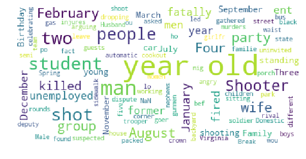

```python
from wordcloud import WordCloud, STOPWORDS
stopwords = set(STOPWORDS)
wordcloud = WordCloud(background_color='white',stopwords=stopwords,max_words=100,
                      max_font_size=40).generate(str(cdata1['Summary']))
plt.figure(figsize=(10,7))
plt.imshow(wordcloud)
plt.axis('off')
plt.show()
```

## 8⃣️ 🔫枪支导致的暴力事件

- 这是我目前找到的一份比较完整部分国家枪支拥有率的数据（2007年），虽然数据久了点，但是还能通过以前的数据来看现在。
- 首当其冲的还是美国🇺🇸，枪支数量的泛滥，也使得**美国枪支暴力事件位居发达国家之首**。
- 作为一个国家，美国与枪支有着深远而持久的联系。自美国建国以来，枪支已融入美国社会的体系，对许多美国人而言，枪支仍然是他们的骄傲。无论是狩猎，运动射击还是个人保护，大多数枪支拥有者都将携带武器的权利视为自由的核心。同时，与枪支有关的暴力活动的结果动摇了整个国家，关于枪支政策的辩论仍然两极分化。

```python
from pyecharts.faker import Faker
from pyecharts import options as opts
from pyecharts.charts import Pie


# 读入数据
dff = pd.read_csv('own.csv')

# 提取country和average firearms per 100 people
# 降序
dd= dff[['country','Average']]
dd1=dd.sort_values('Average',ascending=False)
dd2=dd1.head(21)


# 写成字典
dd3 =list(dd2.values)


def pie_scroll_legend() -> Pie:
    c = (
        Pie()
        .add(
            "",
            dd3,

            label_opts=opts.LabelOpts(is_show=False),
        )
        .set_global_opts(
            title_opts=opts.TitleOpts(title="枪支拥有率前二十的国家",subtitle="平均每100人拥有枪支"),
            legend_opts=opts.LegendOpts(
                type_="scroll", pos_left="80%", orient="vertical"
            ),
        )
        .set_series_opts(label_opts=opts.LabelOpts(formatter="{b}: {c}"))
    )
    return c

pie_scroll_legend().render_notebook()
```

```python
# 读取“枪支暴力”数据集
df = pd.read_csv('guns.csv', encoding='ISO-8859-1', sep=',' )
df.head()
```

|  | incident_id | date | state | city_or_county | address | n_killed | n_injured | incident_url | source_url | incident_url_fields_missing | ... | participant_age | participant_age_group | participant_gender | participant_name | participant_relationship | participant_status | participant_type | sources | state_house_district | state_senate_district |
| --- | --- | --- | --- | --- | --- | --- | --- | --- | --- | --- | --- | --- | --- | --- | --- | --- | --- | --- | --- | --- | --- |
| 0 | 461105.0 | 2013/1/1 | Pennsylvania | Mckeesport | 1506 Versailles Avenue and Coursin Street | 0.0 | 4.0 | http://www.gunviolencearchive.org/incident/461105 | http://www.post-gazette.com/local/south/2013/0... | False | ... | 0::20 | 0::Adult 18+\|\|1::Adult 18+\|\|2::Adult 18+\|\|3::A... | 0::Male\|\|1::Male\|\|3::Male\|\|4::Female | 0::Julian Sims | NaN | 0::Arrested\|\|1::Injured\|\|2::Injured\|\|3::Injure... | 0::Victim\|\|1::Victim\|\|2::Victim\|\|3::Victim\|\|4:... | http://pittsburgh.cbslocal.com/2013/01/01/4-pe... | NaN | NaN |
| 1 | 460726.0 | 2013/1/1 | California | Hawthorne | 13500 block of Cerise Avenue | 1.0 | 3.0 | http://www.gunviolencearchive.org/incident/460726 | http://www.dailybulletin.com/article/zz/201301... | False | ... | 0::20 | 0::Adult 18+\|\|1::Adult 18+\|\|2::Adult 18+\|\|3::A... | 0::Male | 0::Bernard Gillis | NaN | 0::Killed\|\|1::Injured\|\|2::Injured\|\|3::Injured | 0::Victim\|\|1::Victim\|\|2::Victim\|\|3::Victim\|\|4:... | http://losangeles.cbslocal.com/2013/01/01/man-... | 62.0 | 35.0 |
| 2 | 478855.0 | 2013/1/1 | Ohio | Lorain | 1776 East 28th Street | 1.0 | 3.0 | http://www.gunviolencearchive.org/incident/478855 | http://chronicle.northcoastnow.com/2013/02/14/... | False | ... | 0::25\|\|1::31\|\|2::33\|\|3::34\|\|4::33 | 0::Adult 18+\|\|1::Adult 18+\|\|2::Adult 18+\|\|3::A... | 0::Male\|\|1::Male\|\|2::Male\|\|3::Male\|\|4::Male | 0::Damien Bell\|\|1::Desmen Noble\|\|2::Herman Sea... | NaN | 0::Injured, Unharmed, Arrested\|\|1::Unharmed, A... | 0::Subject-Suspect\|\|1::Subject-Suspect\|\|2::Vic... | http://www.morningjournal.com/general-news/201... | 56.0 | 13.0 |
| 3 | 478925.0 | 2013/1/5 | Colorado | Aurora | 16000 block of East Ithaca Place | 4.0 | 0.0 | http://www.gunviolencearchive.org/incident/478925 | http://www.dailydemocrat.com/20130106/aurora-s... | False | ... | 0::29\|\|1::33\|\|2::56\|\|3::33 | 0::Adult 18+\|\|1::Adult 18+\|\|2::Adult 18+\|\|3::A... | 0::Female\|\|1::Male\|\|2::Male\|\|3::Male | 0::Stacie Philbrook\|\|1::Christopher Ratliffe\|\|... | NaN | 0::Killed\|\|1::Killed\|\|2::Killed\|\|3::Killed | 0::Victim\|\|1::Victim\|\|2::Victim\|\|3::Subject-Su... | http://denver.cbslocal.com/2013/01/06/officer-... | 40.0 | 28.0 |
| 4 | 478959.0 | 2013/1/7 | North Carolina | Greensboro | 307 Mourning Dove Terrace | 2.0 | 2.0 | http://www.gunviolencearchive.org/incident/478959 | http://www.journalnow.com/news/local/article_d... | False | ... | 0::18\|\|1::46\|\|2::14\|\|3::47 | 0::Adult 18+\|\|1::Adult 18+\|\|2::Teen 12-17\|\|3::... | 0::Female\|\|1::Male\|\|2::Male\|\|3::Female | 0::Danielle Imani Jameison\|\|1::Maurice Eugene ... | 3::Family | 0::Injured\|\|1::Injured\|\|2::Killed\|\|3::Killed | 0::Victim\|\|1::Victim\|\|2::Victim\|\|3::Subject-Su... | http://myfox8.com/2013/01/08/update-mother-sho... | 62.0 | 27.0 |

5 rows × 29 columns

```python
# 统计每一列的数据

df.isnull().sum()
```

```
incident_id                    194180
date                           194180
state                          194180
city_or_county                 194180
address                        198884
n_killed                       194180
n_injured                      194180
incident_url                   194180
source_url                     194259
incident_url_fields_missing    194180
congressional_district         199899
gun_stolen                     229246
gun_type                       229217
incident_characteristics       194291
latitude                       196426
location_description           283947
longitude                      196426
n_guns_involved                229217
notes                          219254
participant_age                225296
participant_age_group          205507
participant_gender             204263
participant_name               237261
participant_relationship       305001
participant_status             202014
participant_type               200481
sources                        194442
state_house_district           205564
state_senate_district          204337
dtype: int64
```

```python
#数据基础操作
import pandas as pd # package for high-performance, easy-to-use data structures and data analysis
import numpy as np # fundamental package for scientific computing with Python
#画图
import matplotlib
import matplotlib.pyplot as plt # for plotting
import seaborn as sns # for making plots with seaborn
color = sns.color_palette()
from plotly.offline import init_notebook_mode, iplot,plot
init_notebook_mode(connected=True)
import plotly.graph_objs as go

import squarify
from numpy import array
from matplotlib import cm

'''
数据处理包
'''
from sklearn import preprocessing
import warnings
warnings.filterwarnings("ignore")

from nltk.corpus import stopwords
from textblob import TextBlob
import datetime as dt
import warnings
import string
import time
stop_words = list(set(stopwords.words('english')))
warnings.filterwarnings('ignore')
punctuation = string.punctuation
```

[output not shown]

[output cut: 29 more lines]

[output not shown]

## 9⃣️ ❓哪些城市和州更容易遭受此类攻击？

- 自1865年林肯总统，以及后来的加菲尔德总统、麦金莱总统和肯尼迪总统被暗杀以来，枪支暴力对美国人来说已相当常见。而枪支暴力引发的重大事件，如参议员罗伯特·肯尼迪、民权领袖马丁·路德·金的暗杀，以及科伦拜中学大屠杀、华盛顿特区狙击手攻击事件（Beltway sniper attacks）、弗吉尼亚理工大学校园枪击案，也时常引发对枪支政策的辩论。
- 以下的数据是2013-2018年间超过26万起美国枪支暴力事件的综合记录。
- 🔫可以清晰的看到哪个州发生枪击暴力事件的数量最多。伊利诺伊州(IL) > 加州(CA) > 佛罗里达州(FL) > 德州(TX) > 路易斯安那州(LA)。

```python
df_year=df.groupby(['date'])['n_killed','n_injured'].agg('sum')

states_df = df['state'].value_counts()

statesdf = pd.DataFrame()
statesdf['state'] = states_df.index
statesdf['counts'] = states_df.values

scl = [[0.0, 'rgb(242,240,247)'],[0.2, 'rgb(218,218,235)'],[0.4, 'rgb(188,189,220)'],\
            [0.6, 'rgb(158,154,200)'],[0.8, 'rgb(117,107,177)'],[1.0, 'rgb(84,39,143)']]

state_to_code = {'District of Columbia' : 'dc','Mississippi': 'MS', 'Oklahoma': 'OK', 'Delaware': 'DE', 'Minnesota': 'MN', 'Illinois': 'IL', 'Arkansas': 'AR', 'New Mexico': 'NM', 'Indiana': 'IN', 'Maryland': 'MD', 'Louisiana': 'LA', 'Idaho': 'ID', 'Wyoming': 'WY', 'Tennessee': 'TN', 'Arizona': 'AZ', 'Iowa': 'IA', 'Michigan': 'MI', 'Kansas': 'KS', 'Utah': 'UT', 'Virginia': 'VA', 'Oregon': 'OR', 'Connecticut': 'CT', 'Montana': 'MT', 'California': 'CA', 'Massachusetts': 'MA', 'West Virginia': 'WV', 'South Carolina': 'SC', 'New Hampshire': 'NH', 'Wisconsin': 'WI', 'Vermont': 'VT', 'Georgia': 'GA', 'North Dakota': 'ND', 'Pennsylvania': 'PA', 'Florida': 'FL', 'Alaska': 'AK', 'Kentucky': 'KY', 'Hawaii': 'HI', 'Nebraska': 'NE', 'Missouri': 'MO', 'Ohio': 'OH', 'Alabama': 'AL', 'Rhode Island': 'RI', 'South Dakota': 'SD', 'Colorado': 'CO', 'New Jersey': 'NJ', 'Washington': 'WA', 'North Carolina': 'NC', 'New York': 'NY', 'Texas': 'TX', 'Nevada': 'NV', 'Maine': 'ME'}
statesdf['state_code'] = statesdf['state'].apply(lambda x : state_to_code[x])

data = [ dict(
        type='choropleth',
        colorscale = scl,
        autocolorscale = False,
        locations = statesdf['state_code'],
        z = statesdf['counts'],
        locationmode = 'USA-states',
        text = statesdf['state'],
        marker = dict(
            line = dict (
                color = 'rgb(255,255,255)',
                width = 2
            ) ),
        colorbar = dict(
            title = "Gun Violence Incidents")
        ) ]

layout = dict(
        title = 'State wise number of Gun Violence Incidents',
        geo = dict(
            scope='usa',
            projection=dict( type='albers usa' ),
            showlakes = True,
            lakecolor = 'rgb(255, 255, 255)'),
             )

fig = dict( data=data, layout=layout )
iplot( fig, filename='不同地区枪支暴力事件' )
```

[interactive chart not shown]

- 下面我们来详细看看枪支暴力冲突数量最多的前20个州都有哪些。

```python
temp = df["state"].value_counts().head(20)
#temp.iplot(kind='bar', xTitle = 'State name', yTitle = "No. of incidents", title = 'Top 20 States with highest number of Gun Violence',color="Red")trace1

trace_top20=go.Bar(x=temp.index, y=temp.values)
data=[trace_top20]
iplot(data,filename='枪支暴力冲突数量最多的前20个州')
```

[interactive chart not shown]

📍枪击案多数发生在公寓，高中，公园

[figure not shown]

```python
from PIL import Image
from wordcloud import WordCloud, STOPWORDS
mask = np.array(Image.open('/Users/panzhuoqi/Desktop/usa.png'))
txt = " ".join(df['location_description'].dropna())
wc = WordCloud(mask=mask, max_words=1000, stopwords=STOPWORDS, colormap='copper', background_color='White').generate(txt)
plt.figure(figsize=(16,18))
plt.imshow(wc)
plt.axis('off')
plt.title('');
plt.show()
```